# Métodos Cuantitativos II

v. 2026.01.15

PDF

## ¿Qué son las series de tiempo?

## ¿Qué son las series de tiempo? (1/5)

Por **serie de tiempo** nos referimos a *datos estadísticos* que se recopilan, observan o registran en *intervalos de tiempo regulares*.

## ¿Qué son las series de tiempo? (2/5)

**Calentamiento global**

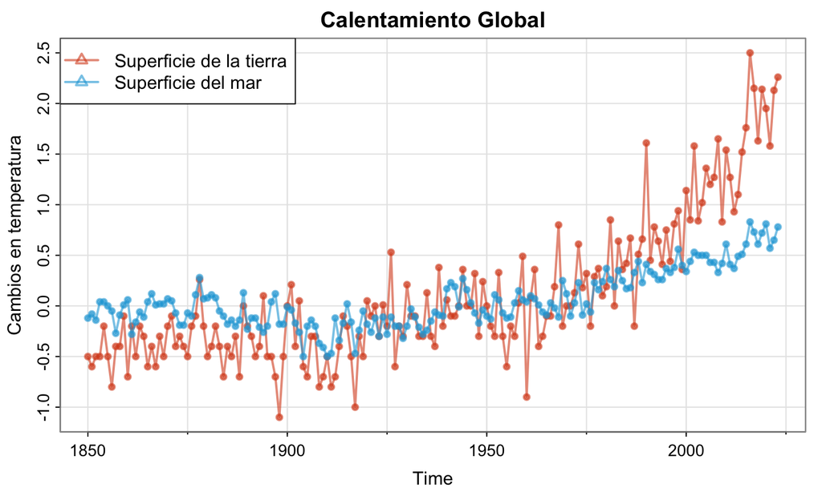

Desviaciones con respecto al promedio del periodo 1950-1980

## ¿Qué son las series de tiempo? (3/5)

**Johnson & Johnson**

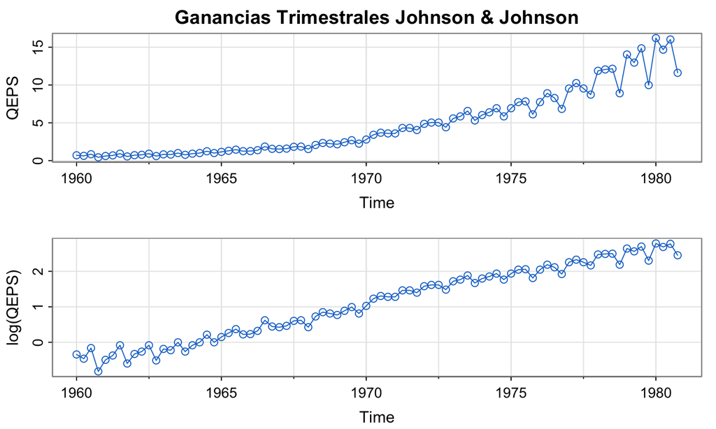

Ganancias trimestrales en niveles y en logaritmos.

## ¿Qué son las series de tiempo? (4/5)

**Dow Jones**

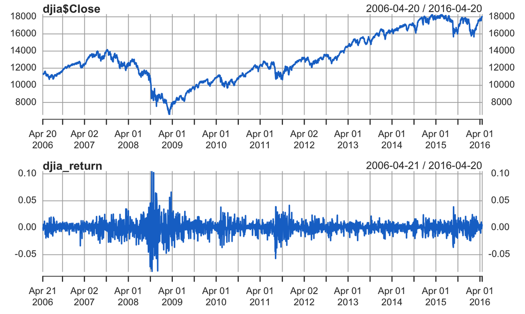

Índice y rendimientos.

## ¿Qué son las series de tiempo? (4/5)

**Crecimiento del PIB de Estados Unidos**

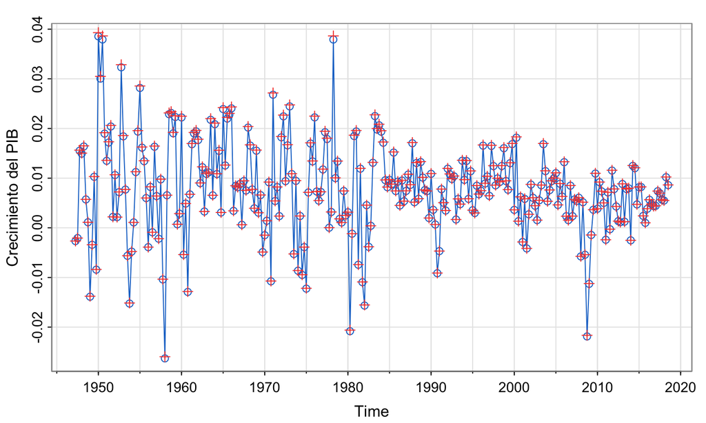

## Modelos de series de tiempo

## ¿En qué consiste un análisis de series temporales?

Un análisis de series temporales consiste en desarrollar modelos matemáticos que nos permitan describir los datos, tomando en cuenta las características específicas de estos:

1. **Tendencia**
2. **Componente estacional**
3. **Componente cíclico**
4. **Componente irregular**

## Ejemplos (1/4)

Un ejemplo de modelo de series temporales es el Ruido Blanco (Gaussiano).

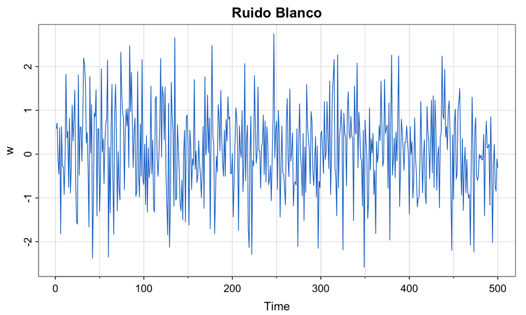

\[ \varepsilon_t \sim iid \mathcal{N}(0,1) \]

## Ejemplos (2/4)

Un modelo de medias móviles.

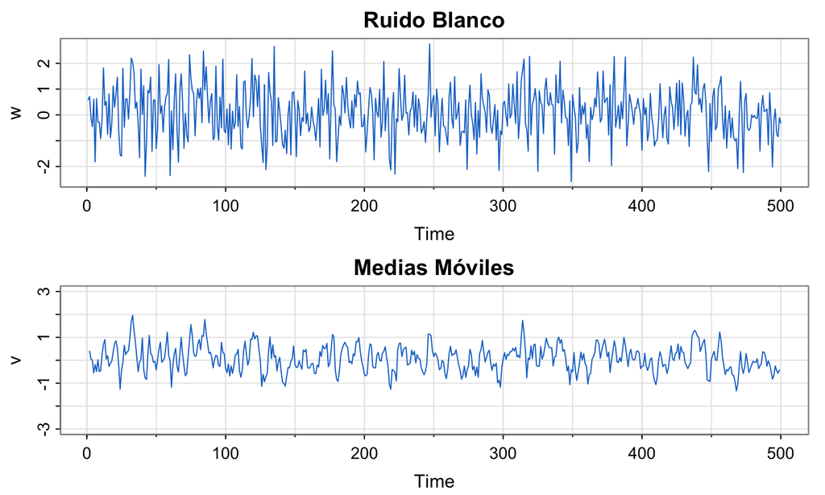

\[ \begin{align} &y_t = \frac{1}{3}(\varepsilon_{t-1}+\varepsilon_{t}+\varepsilon_{t+1}) \\ &\varepsilon_t \sim iid \mathcal{N}(0,1) \end{align} \]

## Ejemplos (3/4)

Modelos autorregresivos

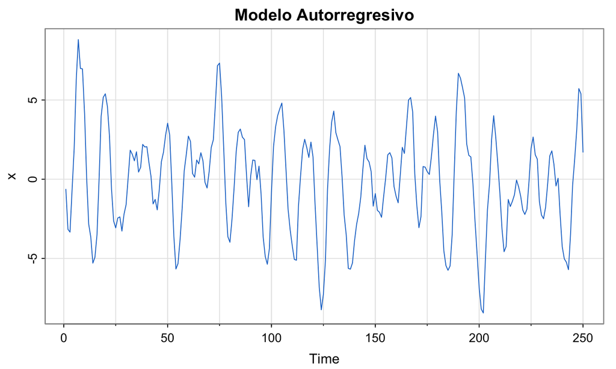

\[ \begin{align} &y_t = 1.5 y_{t-1}-0.75y_{t-2}+\varepsilon_{t} \\ &\varepsilon_t \sim iid \mathcal{N}(0,1) \end{align} \]

## Ejemplos (4/4)

Caminata aleatoria con deriva

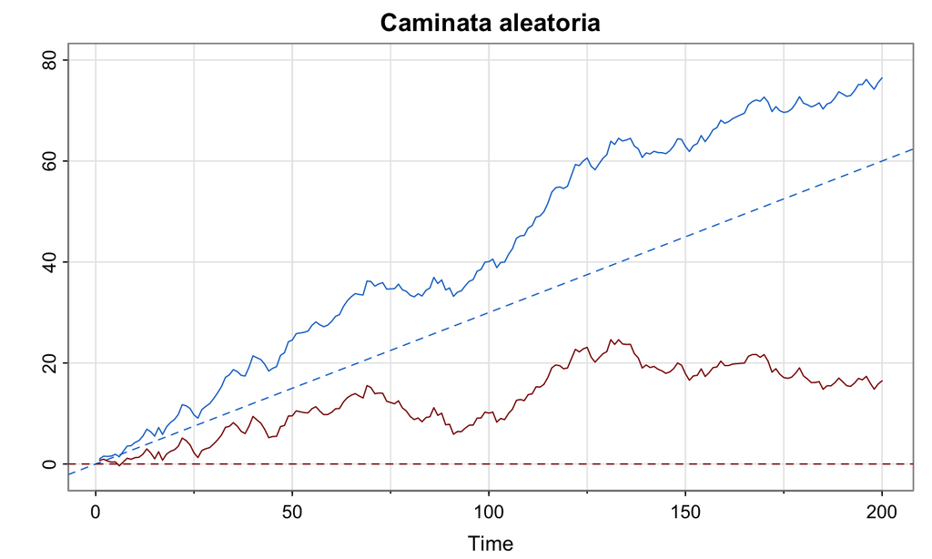

\[ \begin{align} &y_t = 0.3 + y_{t-1}+\varepsilon_{t} \\ &\varepsilon_t \sim iid \mathcal{N}(0,1) \end{align} \]

## Objetivos del curso y contenido

## Objetivos del curso

Este curso sigue un enfoque de trabajo aplicado a problemas reales en finanzas, ingeniería y ciencias sociales:

1. *Explorar y transformar la serie* (niveles, log, tasas de crecimiento)
2. *Diagnosticar patrones* (tendencia, estacionalidad, volatilidad)
3. *Proponer y estimar modelos* (ARMA/ARIMA/SARIMA/VAR/GARCH)
4. *Validar supuestos* (residuales ~ ruido blanco)
5. *Evaluar pronósticos fuera de muestra* (MAE/RMSE/MAPE + intervalos)

## Contenido

1. Introducción
2. Medidas de dependencia serial y estacionariedad
3. Modelos Autorregresivos con Medias Móviles (ARMA)
4. Procesos no estacionarios por tendencia (ARIMA)
5. Modelos estacionales (SARIMA)
6. Modelos de heteroscedasticidad condicional (ARCH/GARCH)
7. Vectores autorregresivos (VAR)
8. Cointegración y corrección de errores (ECM/VECM)

## Software

Utilizaremos principalmente **Gretl**, pero el estudiante puede optar por:

- R / RStudio
- Stata
- Eviews
- Python
- Julia

## Referencias

- **Brockwell**, P., y Davis, R. (2002). *Introduction to Time Series and Forecasting* (Second Edition). Springer.
- **Enders**, W. (2014). *Applied Econometric Time Series* (4th Edition). Wiley.
- **Greene**, W. (2012). *Econometric Analysis* (7th Edition). Prentice Hall
- **Hamilton**, J. (1994). *Time Series Analysis*. Princeton University Press.
- **Shumway**, R., Stoffer, D. (2016). *Time Series Analysis and Applications* (EZ Green Edition).

## Evaluación

- Tareas: 30%
- Lecturas: 10%
- Proyecto Final: 30%
- Examen Final (Teoría): 30%

## Seguimiento

*Moodle*: Campus Digital UG

- Material del curso (diapositivas, datos)
- Distribución de tareas y actividades

*Microsoft Teams*:

- Toda comunicación con el profesor fuera de clase (atencion de dudas, avisos, etc.)